# Investigate User Behavior Of The Startup's App That Sells Food Products. Then Help Managers Make a Decision Regarding The Change of a Font running a Statistical A\B Testing to Test Hypotheses.

by Yotam dadon, Marketing growth data analyst.

- LinkedIn- [Click here for linkedIn](https://www.linkedin.com/in/yotamdadon/)
- Facebook- [Click here for FaceBook](https://www.facebook.com/yotam.dadon/)
- Email- ytmddn@gmail.com

Project objectives:

- Study the sales funnel.
- Find out how users reach the purchase stage.
- Run a A/A/B test regarding the change the fonts for the entire app.
- Help managers decide what decision to make based on the results of an A/A/B test.

#### Data Preprocessing

Conclusion Data Preprocessing

#### Step 1. Open the data file and read the general information

Conclusion Step 1

#### Step 2. Prepare the data for analysis

2.1 Rename the columns in a way that's convenient for you.

2.2 Check for missing values and data types. Correct the data if needed.

2.3 Add a date and time column and a separate column for dates

#### Step2 Conclusions

#### Step 3. Study and check the data

3.1 How many events are in the logs?

3.2 How many users are in the logs?

3.3 What's the average number of events per user?

4. What period of time does the data cover? Find the maximum and the minimum date. Plot a histogram by date and time. Can you be sure that you have equally complete data for the entire period? Older events could end up in some users' logs for technical reasons, and this could skew the overall picture. Find the moment at which the data starts to be complete and ignore the earlier section. What period does the data actually represent?

3.5 Did you lose many events and users when excluding the older data??

3.6 Make sure you have users from all three experimental groups.

#### Step3 Conclusions

#### Step 4. Study the event funnel

4.1 See what events are in the logs and their frequency of occurrence. Sort them by frequency.

4.2 Find the number of users who performed each of these actions. Sort the events by the number of users. Calculate the proportion of users who performed the action at least once.

4.3 In what order do you think the actions took place. Are all of them part of a single sequence? You don't need to take them into account when calculating the funnel.

4.4 Use the event funnel to find the share of users that proceed from each stage to the next. (For instance, for the sequence of events A → B → C, calculate the ratio of users at stage B to the number of users at stage A and the ratio of users at stage C to the number at stage B.)

4.5 At what stage do you lose the most users?

4.6 What share of users make the entire journey from their first event to payment?

#### Step4 Conclusions

#### Step 5. Study the results of the experiment

5.1 How many users are there in each group?.

5.2 We have two control groups in the A/A test, where we check our mechanisms and calculations. See if there is a statistically significant difference between samples 246 and 247.

5.3 Select the most popular event. In each of the control groups, find the number of users who performed this action. Find their share. Check whether the difference between the groups is statistically significant. Repeat the procedure for all other events (it will save time if you create a special function for this test). Can you confirm that the groups were split properly?

5.4 Do the same thing for the group with altered fonts. Compare the results with those of each of the control groups for each event in isolation. Compare the results with the combined results for the control groups. What conclusions can you draw from the experiment?)

5.5 What significance level have you set to test the statistical hypotheses mentioned above? Calculate how many statistical hypothesis tests you carried out. With a statistical significance level of 0.1, one in 10 results could be false. What should the significance level be? If you want to change it, run through the previous steps again and check your conclusions.

#### Step5 Conclusions

### Step 1. Open the data file and read the general information

```python
import pandas as pd
import numpy as np
import datetime as dt
import seaborn as sns
from matplotlib import pyplot as plt
from datetime import datetime
import plotly.express as px
from scipy import stats as st
import math
from scipy import stats
```

```python
#Import the tables
REST_DATA_LOCAL = '/Users/yotamdadon/Documents/Data_Analyst/logs_exp_us.csv'
REST_DATA_ONLINE = '/datasets/logs_exp_us.csv'

try:
    logs_exp = pd.read_csv(REST_DATA_LOCAL, sep='\t')
except:
    logs_exp = pd.read_csv(REST_DATA_ONLINE, sep='\t')


logs_exp.columns = logs_exp.columns.str.lower()
```

```python
logs_exp.head()
```

|  | eventname | deviceidhash | eventtimestamp | expid |
| --- | --- | --- | --- | --- |
| 0 | MainScreenAppear | 4575588528974610257 | 1564029816 | 246 |
| 1 | MainScreenAppear | 7416695313311560658 | 1564053102 | 246 |
| 2 | PaymentScreenSuccessful | 3518123091307005509 | 1564054127 | 248 |
| 3 | CartScreenAppear | 3518123091307005509 | 1564054127 | 248 |
| 4 | PaymentScreenSuccessful | 6217807653094995999 | 1564055322 | 248 |

```python
#checking for duplicates
logs_exp.info()
logs_exp.duplicated().sum()
```

```
<class 'pandas.core.frame.DataFrame'>
RangeIndex: 244126 entries, 0 to 244125
Data columns (total 4 columns):
 #   Column          Non-Null Count   Dtype
---  ------          --------------   -----
 0   eventname       244126 non-null  object
 1   deviceidhash    244126 non-null  int64
 2   eventtimestamp  244126 non-null  int64
 3   expid           244126 non-null  int64
dtypes: int64(3), object(1)
memory usage: 7.5+ MB
```

```
413
```

```python
#drop duplicates because the portion of the duplicates is negligible
logs_exp = logs_exp.drop_duplicates()
len(logs_exp)
```

```
243713
```

## Conclusions Step 1

413 duplicates where found, they where removed from the dataframe.

- rest_data: 243713 rows, 4 columns (eventname, deviceidhash, eventtimestamp, expid)

The data looks solid.

## Step 2. Prepare the data for analysis

### Renaming the columns for convenience.

```python
logs_exp.columns = ('event_name','user_id','event_time_stamp','exp_id')
```

### Check for missing values and data types. Correct the data if needed.

```python
logs_exp.isnull().sum()
```

```
event_name          0
user_id             0
event_time_stamp    0
exp_id              0
dtype: int64
```

```python
logs_exp.dtypes
```

```
event_name          object
user_id              int64
event_time_stamp     int64
exp_id               int64
dtype: object
```

```python
#changing the event_time_stamp column data type from INT to datetime
logs_exp['event_time_stamp'] = logs_exp['event_time_stamp'].apply(lambda x: datetime.fromtimestamp(x))
```

### Adding a date and time column and a separate column for dates.

```python
#adding a date column
logs_exp['event_date'] = logs_exp['event_time_stamp'].dt.date
```

## Step 2 Conclusions

```
- Column names had no spaces, underscores added for spaces
- Event time stamp was int, changed to datetime
- A 'date' column was added in datetime format.
```

## Step 3. Study and check the data

### How many events are in the logs?

```python
# Using len function on the index to count events
print('There are {} events in the log'.format(len(logs_exp.index)))
```

```
There are 243713 events in the log
```

### How many users are in the logs?

```python
#Nuniqe will help to count uniqe users
print('There are {} events in the log'.format(logs_exp.user_id.nunique()))
```

```
There are 7551 events in the log
```

### What's the average number of events per user?

```python
#groupby user id and event name with mean
print('The average number of events per user is {}'.format(logs_exp.groupby('user_id')['event_name'].count().mean()))
```

```
The average number of events per user is 32.27559263673685
```

### What period of time does the data cover? Find the maximum and the minimum date.

```python
#Group the logs by date to see what period of time we are dealing with
period= logs_exp.groupby('event_date',as_index=True)['event_name'].count().to_frame().reset_index()
period
```

|  | event_date | event_name |
| --- | --- | --- |
| 0 | 2019-07-25 | 9 |
| 1 | 2019-07-26 | 30 |
| 2 | 2019-07-27 | 55 |
| 3 | 2019-07-28 | 104 |
| 4 | 2019-07-29 | 181 |
| 5 | 2019-07-30 | 397 |
| 6 | 2019-07-31 | 1213 |
| 7 | 2019-08-01 | 35767 |
| 8 | 2019-08-02 | 35571 |
| 9 | 2019-08-03 | 33602 |
| 10 | 2019-08-04 | 32583 |
| 11 | 2019-08-05 | 36075 |
| 12 | 2019-08-06 | 36270 |
| 13 | 2019-08-07 | 31788 |
| 14 | 2019-08-08 | 68 |

```python
#get min and max values and preiod duration
display(period['event_date'].min())
display(period['event_date'].max())
display(period['event_date'].max()-period['event_date'].min())
```

```
datetime.date(2019, 7, 25)
```

```
datetime.date(2019, 8, 8)
```

```
datetime.timedelta(days=14)
```

The data covers a period from 25-07-2019 (our minimum date) to 08-08-2019(our maximum date) 14 days in total.

### Plot a histogram by date and time. Can you be sure that you have equally complete data for the entire period? Older events could end up in some users' logs for technical reasons, and this could skew the overall picture. Find the moment at which the data starts to be complete and ignore the earlier section. What period does the data actually represent?

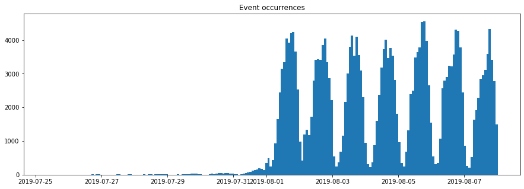

```python
from pandas.plotting import register_matplotlib_converters
register_matplotlib_converters()

plt.figure(figsize=(15, 5))
plt.hist(x='event_time_stamp', data=logs_exp, bins=200)
plt.title('Event occurrences');
```

### Did you lose many events and users when excluding the older data??

```python
# Lets ensure the 'event_date' column is in date format
logs_exp['event_date'] = pd.to_datetime(logs_exp['event_date'])
# set the desired start date and end date to filter the data frame with
start_date = '25-07-2019'
end_date = '31-07-2019'
# set the mask
mask = (logs_exp['event_date'] > start_date) & (logs_exp['event_date'] <= end_date)
```

```python
# assign mask to older_data to return the rows with event_date between our specified start/end dates
excluded_data = logs_exp.loc[mask]
excluded_events_count = excluded_data['event_name'].count()
all_events_count = logs_exp['event_name'].count()
lost_events_prop = (excluded_events_count/all_events_count)

excluded_unique_users = excluded_data['user_id'].nunique()
lost_users_prop = excluded_data['user_id'].nunique()/logs_exp['user_id'].nunique()
```

```python
     print('We excluded {} events'.format(excluded_events_count))
     print('Lost events are {:,.2%} from the log'.format(lost_events_prop))
     print('We excluded {} users'.format(excluded_unique_users))
     print('Lost users are {:,.2%} from the log'.format(lost_users_prop))
```

```
We excluded 1980 events
Lost events are 0.81% from the log
We excluded 1312 users
Lost users are 17.38% from the log
```

## Make sure you have users from all three experimental groups.

```python
#To know if we have users from all experimental groups we need to filter out the desired dates from the main dataframe
# Lets ensure the 'event_date' column is in date format
logs_exp['event_date'] = pd.to_datetime(logs_exp['event_date'])
start_date_ = '31-07-2019'
end_date_ = '08-08-2019'
# set the mask
mask_ = (logs_exp['event_date'] > start_date_) & (logs_exp['event_date'] <= end_date_)
new_data = logs_exp.loc[mask_]
new_data['exp_id'].value_counts()
```

```
248    84875
246    79556
247    77293
Name: exp_id, dtype: int64
```

Yes, we have users from all three experimental groups.

## Step 4. Study the event funnel

### See what events are in the logs and their frequency of occurrence. Sort them by frequency.

```python
from __future__ import division
pd.options.display.float_format = '{:.2f}%'.format
f = new_data['event_name'].count()
event_count = new_data.event_name.value_counts()
event_frequency = (event_count/ f)
display(event_frequency)
```

```
MainScreenAppear          0.49%
OffersScreenAppear        0.19%
CartScreenAppear          0.18%
PaymentScreenSuccessful   0.14%
Tutorial                  0.00%
Name: event_name, dtype: float64
```

MainScreenAppear is the most frequent, probably it is the first screen the user encounters.

### Find the number of users who performed each of these actions. Sort the events by the number of users. Calculate the proportion of users who performed the action at least once.

```python
users_actions_cnt = new_data.groupby('event_name').agg({'user_id': 'count'}).sort_values(by='user_id', ascending = False)
action_per_user = new_data.groupby('event_name').agg({'user_id': 'nunique'}).sort_values(by='user_id', ascending = False)
display(users_actions_cnt)
display(action_per_user)
```

| event_name | user_id |
| --- | --- |
| MainScreenAppear | 117889 |
| OffersScreenAppear | 46531 |
| CartScreenAppear | 42343 |
| PaymentScreenSuccessful | 33951 |
| Tutorial | 1010 |

| event_name | user_id |
| --- | --- |
| MainScreenAppear | 7423 |
| OffersScreenAppear | 4597 |
| CartScreenAppear | 3736 |
| PaymentScreenSuccessful | 3540 |
| Tutorial | 843 |

```python
h = (action_per_user/ users_actions_cnt).sort_values(by = 'user_id', ascending = False)
h
```

| event_name | user_id |
| --- | --- |
| Tutorial | 0.83% |
| PaymentScreenSuccessful | 0.10% |
| OffersScreenAppear | 0.10% |
| CartScreenAppear | 0.09% |
| MainScreenAppear | 0.06% |

MainScreenApper is the most frequent event, the proportion of unique users to event accurance is 6% meaning that only 6% of the total MainScreenApper events are unique users.

another intreasting fact is the Tutorial event, 80 percent of the Tutorial event are unique users. Makes sence.

### In what order do you think the actions took place. Are all of them part of a single sequence? You don't need to take them into account when calculating the funnel.

The suggested Funnel is: MainScreenAppear-> OffersScreenAppear-> CartScreenAppear -> PaymentScreenSuccessful

Tutorial has fell out becuase it is redundant

### Use the event funnel to find the share of users that proceed from each stage to the next. (For instance, for the sequence of events A → B → C, calculate the ratio of users at stage B to the number of users at stage A and the ratio of users at stage C to the number at stage B.

```python
reorderlist = ['Tutorial','MainScreenAppear','OffersScreenAppear','CartScreenAppear','PaymentScreenSuccessful']
funnel = action_per_user.reindex(reorderlist)
funnel.drop("Tutorial", axis=0, inplace=True)
funnel['rate'] = funnel['user_id']/funnel['user_id'].shift(+1)
funnel
```

| event_name | user_id | rate |
| --- | --- | --- |
| MainScreenAppear | 7423 | nan% |
| OffersScreenAppear | 4597 | 0.62% |
| CartScreenAppear | 3736 | 0.81% |
| PaymentScreenSuccessful | 3540 | 0.95% |

```python
from plotly import graph_objects as go

fig = go.Figure(go.Funnel(
    y = funnel.index,
    x = funnel['user_id'],
    textposition = "inside",
    textinfo = "value+percent previous",
    opacity = 0.65, marker = {"color": ["deepskyblue", "lightsalmon", "tan", "teal", "silver"],
    "line": {"width": [4, 2, 2, 3, 1, 1], "color": ["wheat", "wheat", "blue", "wheat", "wheat"]}},
    connector = {"line": {"color": "royalblue", "dash": "dot", "width": 3}})
    )
fig.update_layout(title_text="Conversion Funnel")
fig.show()
```

[interactive chart not shown]

### At what stage do you lose the most users?

We lose the most users on the OffersScreenAppear stage, we lose rufly 40% of the previos screen. maybe the fonts in the main page dont convince our users to stay.

### What share of users make the entire journey from their first event to payment?

47.7% of useres make it to the payment stage

## Step 4 Conclusions

another intreasting fact is the Tutorial event, 80 percent of the Tutorial event are unique users. Makes sence.

## Step 5. Study the results of the experiment

### How many users are there in each group?.

First we need to decide on a sample size. I will use the online tool:https://www.evanmiller.org/ab-testing/sample-size.html to help use decide.

We want to increace the MainScreenAppear 48% -> OffersScreenAppear 19.2% conversion rate, from a baseline of 19.2% to 25%. according to the online sample size calculator "evanmiller" we need a sample size of 1,064 users per variation.

```python
new_data.groupby('exp_id')['user_id'].nunique()
```

```
exp_id
246    2484
247    2517
248    2537
Name: user_id, dtype: int64
```

The users are split into three groups: two control groups get the old fonts and one test group gets the new ones.

1) Group 246 --> 2484 Users  
2) Group 247 --> 2517 Users  
3) Group 248 --> 2537 Users

### We have two control groups in the A/A test, where we check our mechanisms and calculations. See if there is a statistically significant difference between samples 246 and 247.

For calculating proportions we need to know the number of users in the group. We will call groups 246 and 247 - control_1 and control_2

```python
control_1=new_data[new_data.exp_id==246]['user_id'].unique()
control_2=new_data[new_data.exp_id==247]['user_id'].unique()

print('control 1 - 246, amount of users:', len(control_1))
print('control 2 - 247, amount of users:', len(control_2))
```

```
control 1 - 246, amount of users: 2484
control 2 - 247, amount of users: 2517
```

In order to check whether two control groups are significantly different in each event we will creat a pivot table with the diferent groups as columns and the diferent events as rows.

```python
pivot = new_data.pivot_table(index='event_name', values='user_id', columns='exp_id', aggfunc=lambda x: x.nunique()).reset_index()
pivot
```

| exp_id | event_name | 246 | 247 | 248 |
| --- | --- | --- | --- | --- |
| 0 | CartScreenAppear | 1266 | 1239 | 1231 |
| 1 | MainScreenAppear | 2450 | 2479 | 2494 |
| 2 | OffersScreenAppear | 1542 | 1524 | 1531 |
| 3 | PaymentScreenSuccessful | 1200 | 1158 | 1182 |
| 4 | Tutorial | 278 | 284 | 281 |

We want to check Whether there is a significant difference in proportion - "Is the share of users (from all users in the test) that had "CartScreenAppear of one test group is statistically different from another?"

H0 = there is no significant diference of proportions between the two tested groups  
H1 = there is a significant diference of proportions between the two tested groups

```python
def check_hypothesis(groups_dataframe,group1,group2,main_dataframe, event, alpha=0.05):
    #let's start with successes, using
    successes1 =  groups_dataframe[groups_dataframe.event_name==event][group1].iloc[0]
    successes2 = groups_dataframe[groups_dataframe.event_name==event][group2].iloc[0]

    #for trials we can go back to original df or used a pre-aggregated data
    trials1=main_dataframe[main_dataframe.exp_id==group1]['user_id'].nunique()
    trials2=main_dataframe[main_dataframe.exp_id==group2]['user_id'].nunique()


  #proportion for success in the first group
    p1 = successes1/trials1

   #proportion for success in the second group
    p2 = successes2/trials2

    # proportion in a combined dataset
    p_combined = (successes1 + successes2) / (trials1 + trials2)


    difference = p1 - p2


    z_value = difference / math.sqrt(p_combined * (1 - p_combined) * (1/trials1 + 1/trials2))


    distr = stats.norm(0, 1)


    p_value = (1 - distr.cdf(abs(z_value))) * 2

    print('p-value: ', p_value)

    if (p_value < alpha):
        print("Reject H0 for",event, 'and groups',group1,group2)
    else:
        print("Fail to Reject H0 for", event,'and groups',group1,group2)
```

```python
check_hypothesis(pivot ,246,247,new_data, 'OffersScreenAppear', alpha=0.05)
```

```
p-value:  0.26698769175859516
Fail to Reject H0 for OffersScreenAppear and groups 246 247
```

### Select the most popular event. In each of the control groups, find the number of users who performed this action. Find their share. Check whether the difference between the groups is statistically significant. Repeat the procedure for all other events (it will save time if you create a special function for this test). Can you confirm that the groups were split properly?

```python
for i in pivot.event_name.unique():
    check_hypothesis(pivot, 246, 247, new_data, 'OffersScreenAppear', alpha=0.05)
```

```
p-value:  0.26698769175859516
Fail to Reject H0 for OffersScreenAppear and groups 246 247
p-value:  0.26698769175859516
Fail to Reject H0 for OffersScreenAppear and groups 246 247
p-value:  0.26698769175859516
Fail to Reject H0 for OffersScreenAppear and groups 246 247
p-value:  0.26698769175859516
Fail to Reject H0 for OffersScreenAppear and groups 246 247
p-value:  0.26698769175859516
Fail to Reject H0 for OffersScreenAppear and groups 246 247
```

### Do the same thing for the group with altered fonts. Compare the results with those of each of the control groups for each event in isolation. Compare the results with the combined results for the control groups. What conclusions can you draw from the experiment?

```python
for i in pivot.event_name.unique():
    check_hypothesis(pivot, 246, 248, new_data, 'OffersScreenAppear', alpha=0.05)
```

```
p-value:  0.20836205402738917
Fail to Reject H0 for OffersScreenAppear and groups 246 248
p-value:  0.20836205402738917
Fail to Reject H0 for OffersScreenAppear and groups 246 248
p-value:  0.20836205402738917
Fail to Reject H0 for OffersScreenAppear and groups 246 248
p-value:  0.20836205402738917
Fail to Reject H0 for OffersScreenAppear and groups 246 248
p-value:  0.20836205402738917
Fail to Reject H0 for OffersScreenAppear and groups 246 248
```

```python
for i in pivot.event_name.unique():
    check_hypothesis(pivot, 247, 248, new_data, 'OffersScreenAppear', alpha=0.05)
```

```
p-value:  0.8835956656016957
Fail to Reject H0 for OffersScreenAppear and groups 247 248
p-value:  0.8835956656016957
Fail to Reject H0 for OffersScreenAppear and groups 247 248
p-value:  0.8835956656016957
Fail to Reject H0 for OffersScreenAppear and groups 247 248
p-value:  0.8835956656016957
Fail to Reject H0 for OffersScreenAppear and groups 247 248
p-value:  0.8835956656016957
Fail to Reject H0 for OffersScreenAppear and groups 247 248
```

```python
pivot[249] = pivot[246] + pivot[247]
pivot
```

| exp_id | event_name | 246 | 247 | 248 | 249 |
| --- | --- | --- | --- | --- | --- |
| 0 | CartScreenAppear | 1266 | 1239 | 1231 | 2505 |
| 1 | MainScreenAppear | 2450 | 2479 | 2494 | 4929 |
| 2 | OffersScreenAppear | 1542 | 1524 | 1531 | 3066 |
| 3 | PaymentScreenSuccessful | 1200 | 1158 | 1182 | 2358 |
| 4 | Tutorial | 278 | 284 | 281 | 562 |

```python
new_data
```

|  | event_name | user_id | event_time_stamp | exp_id | event_date |
| --- | --- | --- | --- | --- | --- |
| 1990 | MainScreenAppear | 7701922487875823903 | 2019-08-01 00:00:57 | 247 | 2019-08-01 |
| 1991 | MainScreenAppear | 2539077412200498909 | 2019-08-01 00:01:45 | 247 | 2019-08-01 |
| 1992 | OffersScreenAppear | 3286987355161301427 | 2019-08-01 00:02:21 | 248 | 2019-08-01 |
| 1993 | OffersScreenAppear | 3187166762535343300 | 2019-08-01 00:02:23 | 247 | 2019-08-01 |
| 1994 | MainScreenAppear | 1118952406011435924 | 2019-08-01 00:03:25 | 248 | 2019-08-01 |
| ... | ... | ... | ... | ... | ... |
| 244121 | MainScreenAppear | 4599628364049201812 | 2019-08-08 00:12:25 | 247 | 2019-08-08 |
| 244122 | MainScreenAppear | 5849806612437486590 | 2019-08-08 00:13:59 | 246 | 2019-08-08 |
| 244123 | MainScreenAppear | 5746969938801999050 | 2019-08-08 00:14:43 | 246 | 2019-08-08 |
| 244124 | MainScreenAppear | 5746969938801999050 | 2019-08-08 00:14:58 | 246 | 2019-08-08 |
| 244125 | OffersScreenAppear | 5746969938801999050 | 2019-08-08 00:15:17 | 246 | 2019-08-08 |

241724 rows × 5 columns

```python
def check_hypothesis_(group1,group2, event, alpha=0.05):
    #let's start with successes, using
    successes1 =  pivot[pivot.event_name==event][group1].iloc[0]
    successes2 = pivot[pivot.event_name==event][group2].iloc[0]

    #for trials we can go back to original df or used a pre-aggregated data
    trials1=new_data[new_data.exp_id!=248]['user_id'].nunique()
    trials2=new_data[new_data.exp_id==group2]['user_id'].nunique()


  #proportion for success in the first group
    p1 = successes1/trials1

   #proportion for success in the second group
    p2 = successes2/trials2

    # proportion in a combined dataset
    p_combined = (successes1 + successes2) / (trials1 + trials2)


    difference = p1 - p2


    z_value = difference / math.sqrt(p_combined * (1 - p_combined) * (1/trials1 + 1/trials2))


    distr = stats.norm(0, 1)


    p_value = (1 - distr.cdf(abs(z_value))) * 2

    print('p-value: ', p_value)

    if (p_value < alpha):
        print("Reject H0 for",event, 'and groups',group1,group2)
    else:
        print("Fail to Reject H0 for", event,'and groups',group1,group2)
```

```python
for i in pivot.event_name.unique():
    check_hypothesis_(249,248, i, alpha=0.05)
```

```
p-value:  0.19819340844527744
Fail to Reject H0 for CartScreenAppear and groups 249 248
p-value:  0.39298914928006035
Fail to Reject H0 for MainScreenAppear and groups 249 248
p-value:  0.418998284007599
Fail to Reject H0 for OffersScreenAppear and groups 249 248
p-value:  0.6452057673098244
Fail to Reject H0 for PaymentScreenSuccessful and groups 249 248
p-value:  0.8333049080125807
Fail to Reject H0 for Tutorial and groups 249 248
```

Apparantly the test group 248 didnt have significant results, the font changing did not work.

### What significance level have you set to test the statistical hypotheses mentioned above? Calculate how many statistical hypothesis tests you carried out. With a statistical significance level of 0.1, one in 10 results could be false. What should the significance level be? If you want to change it, run through the previous steps again and check your conclusions.

Making several comparisons with the same data is called multiple testing. The thing about it is that the probability of making a type I error increases with each new hypothesis test.

in our case p.value>alpha so lowering the alpha wont change our results. so there is no need to change alpha and run tests again.

### Step5 Conclusions

- The users are split into three groups: two control groups get the old fonts and one test group gets the new ones.

1) Group 246 --> 2484 Users  
2) Group 247 --> 2517 Users  
3) Group 248 --> 2537 Users

- For calculating proportions we need to know the number of users in the group. We will call groups 246 and 247 - control_1 and control_2  
  control 1 - 246, amount of users: 2484  
  control 2 - 247, amount of users: 2517
- We want to check Whether there is a significant difference in proportion

H0 = there is no significant diference of proportions between the two tested groups  
H1 = there is a significant diference of proportions between the two tested groups

it seams that the font change did not effect the user behaviour between any of the steps in the funnel.

# General Conclusions

another intreasting fact is the Tutorial event, 80 percent of the Tutorial event are unique users. Makes sence.

H0 = there is no significant diference of proportions between the two tested groups  
H1 = there is a significant diference of proportions between the two tested groups

**it seams that the font change did not significantly effect the conversion rate between any of the steps in the funnel.**